# Estimated Parish Level Greenhouse Gas (GHG) Emissions

Badingham

Ben Anderson (@dataknut)

Last run at: 2021-12-09 19:45:35

# 1 What are we looking at?

The graphs that follow show the estimated emissions per year for the selected parish. They show this using two methods:

- [Territorial-based](https://www.ons.gov.uk/economy/environmentalaccounts/articles/netzeroandthedifferentofficialmeasuresoftheuksgreenhousegasemissions/2019-07-24#measuring-the-uks-progress-to-net-zero) emissions: the emissions that come from activities carried out *in* the parish
- [Consumption-based](https://www.ons.gov.uk/economy/environmentalaccounts/articles/netzeroandthedifferentofficialmeasuresoftheuksgreenhousegasemissions/2019-07-24#the-uks-carbon-footprint) emissions: the emissions that come from the production of the goods and services we consume, wherever they are emitted

The per-household emissions for each parish are also compared with the per-household emissions for the district in which the parish sits. This lets you see how above or below ‘average’ for your district you are.

The data used comes from a University of Exeter/Centre for Sustainable Energy [project](https://impact-tool.org.uk/about) and it combines:

- data that can be measured at parish level (e.g. gas & electricity) and
- data that are estimated for each Parish based on the kinds of people that live there (Census data), transport infrastructure, land-use and local business/commercial activity.

As the [CSE guidance](https://impact-tool.org.uk/using-the-tool) notes, the parish level territorial estimates are perhaps best used to paint a broad brush picture of ’the big things’ that are *likely* to be the main parish level emissions sources. Sometimes this might highlight major through-roads as large emissions sources which can seem unfair if most of the traffic is from ‘out of parish’. It can also identify a local industrial or agricultural activity as a major source. The parish may not think it can influence this but it could lead to constructive discussions with those businesses (for example).

The consumption estimates are best used to show which aspects of the parish’ consumption are *likely* to be the biggest contributors and thus a) what we should try to do/use less of and/or b) how we should deliberately spend in ways that reduce our emissions footprint. Of course if 100% of the parish never fly and never eat meat/fish then the estimated parish footprints will be wrong… etc

Further information:

- the [differences](https://impact-tool.org.uk/using-the-tool) between territorial-based and consumption-based emissions
- use the tool [online](https://impact-tool.org.uk/footprint/search)
- guide to [using the tool](https://impact-tool.org.uk/using-the-tool) online
- the [methods](https://impact-tool.org.uk/methodology) used to estimate the emissions
- download the data for yourself

# 2 Territorial emissions: Badingham parish

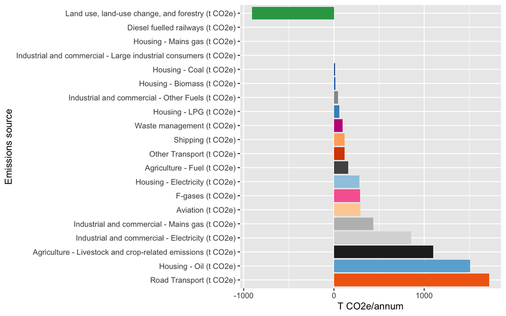

Total territorial emissions: 6192.8291997`